# EDA of effect of mean functions on GP fits to lightcurve 428_…

## 2.2 MCMC Plots

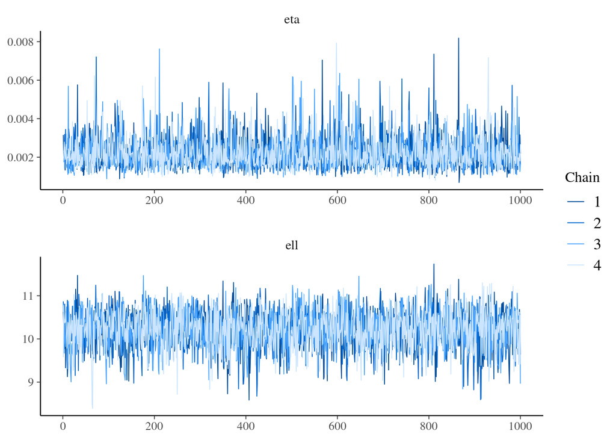

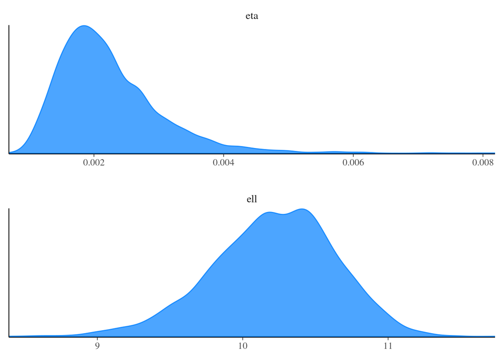

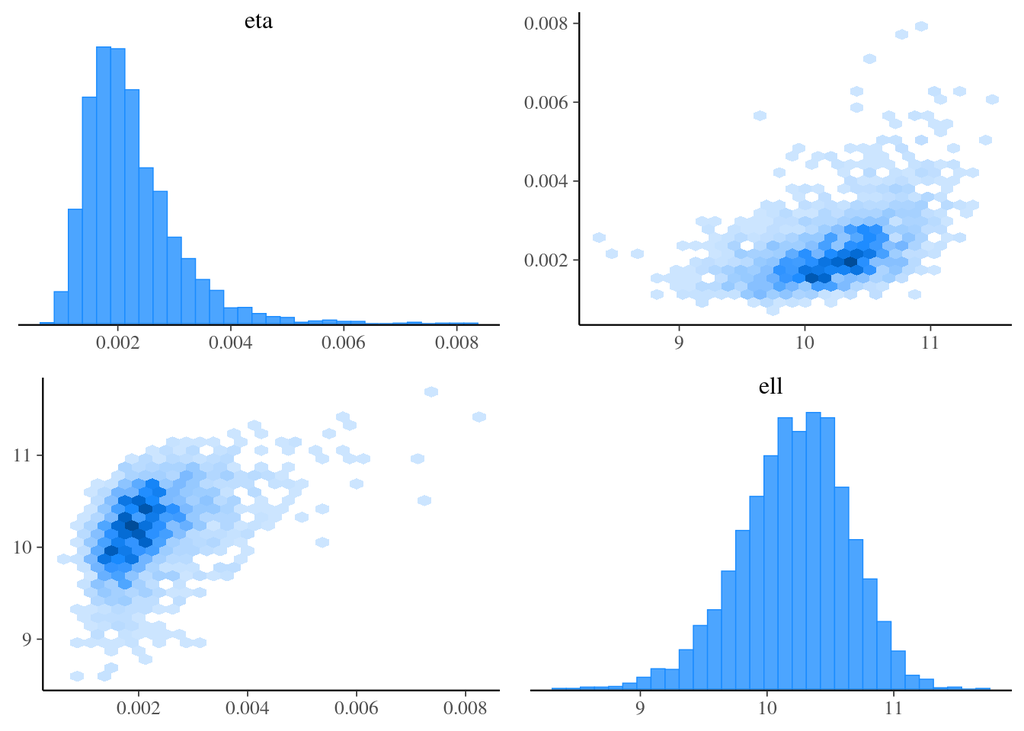

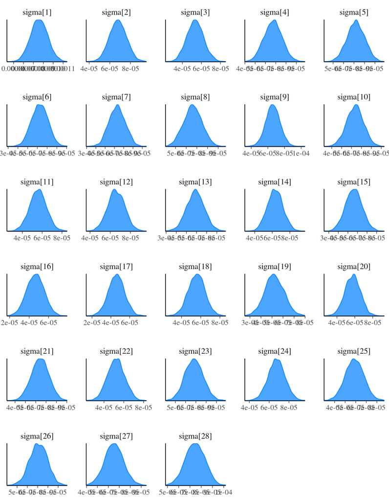

## 2.3 Posterior Predictive Samples

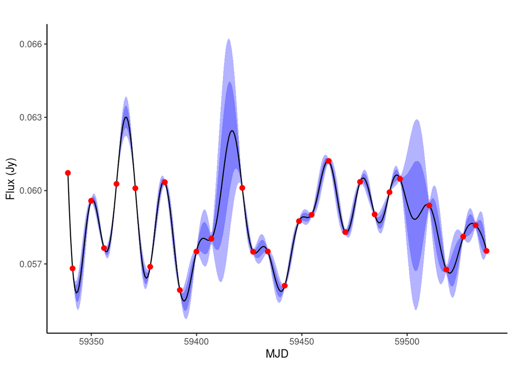

By including the observed observational errors for setting priors on the Gaussian noise of each observation, the fitted median passes through each of the observed points.

## 2.4 PSD

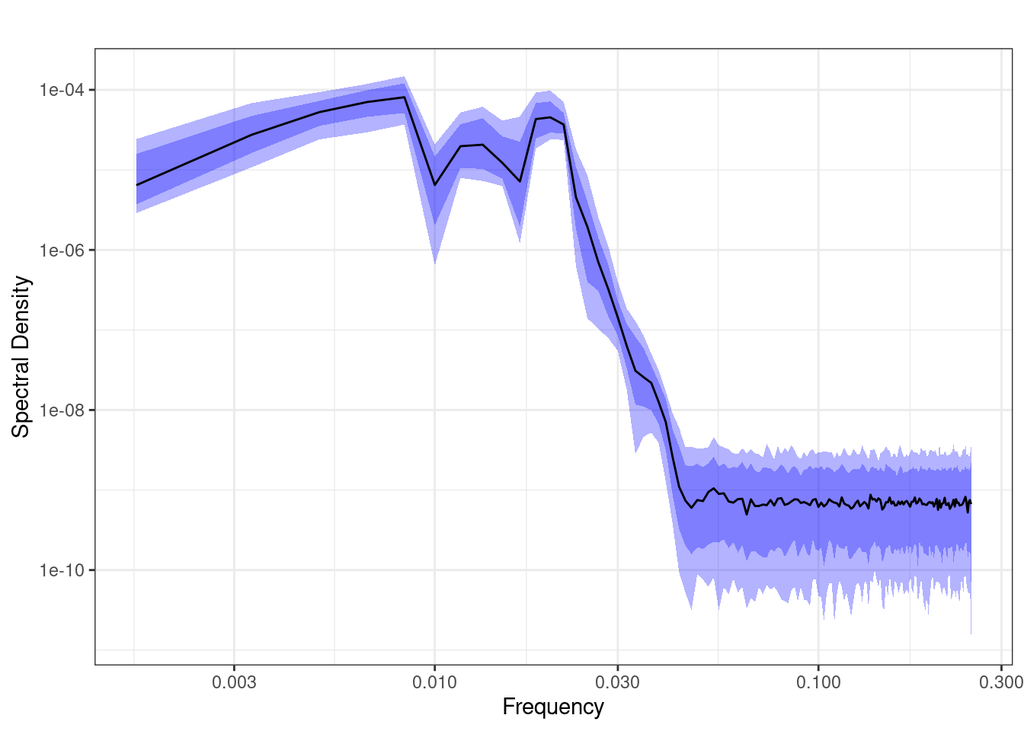

# 3 Flat zero mean function, mean centred data Model

- Zero constant mean function.
- Squared exponential kernel function.
- Heteroskedastic (Gaussian) noise.
- Incorporate data on error in observations of each $y_i$.
- Observations have had mean subtracted from them.

$$y'_i = y_i - \bar{y}$$

$$y'_i \sim \mathcal{N}(f(x_i), \sigma_i^2)$$

$$f \sim \mathcal{GP}(\boldsymbol{0}, k(x, x'))$$

$$k(x,x') = \eta \exp\left\{ -\frac{1}{2}\frac{(x - x')^2}{\ell^2}\right\}$$

$$\ell \sim \mathrm{InvGamma}(5,5)$$

$$\eta \sim \mathcal{N}^+(0,1)$$

$$\sigma_i \sim \mathcal{N}^+(\textrm{stderr}(y_i), \mathrm{Var}(\textrm{stderr}(\boldsymbol{y})))$$

## 3.1 MCMC Results

```
$num_divergent
[1] 0 0 0 0

$num_max_treedepth
[1] 0 0 0 0

$ebfmi
[1] 0.9211750 1.0697978 0.9473214 1.0350747
```

```
 variable     mean   median       sd      mad       q5      q95     rhat
 eta      0.000003 0.000002 0.000001 0.000001 0.000002 0.000004 1.000635
 ell      0.963869 0.907481 0.348277 0.316343 0.517156 1.618919 1.000994
 sigma[1] 0.000086 0.000086 0.000009 0.000009 0.000071 0.000100 1.001172
 ess_bulk ess_tail
     5929     3029
     6476     3005
     7160     2859
```

## 3.2 MCMC Plots

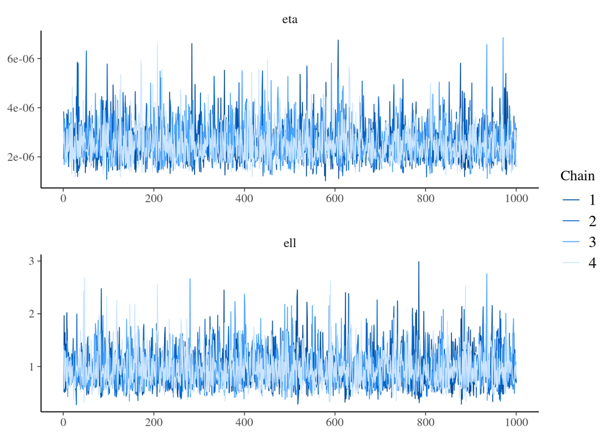

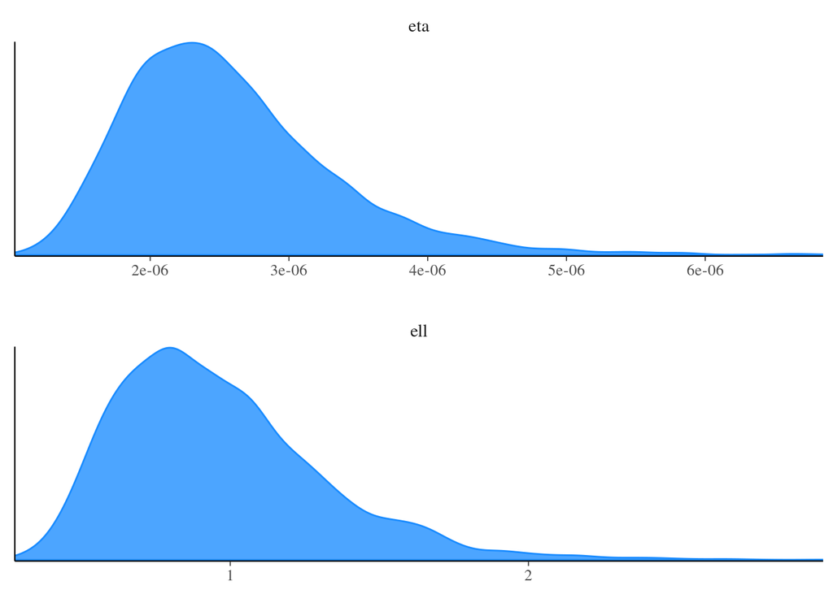

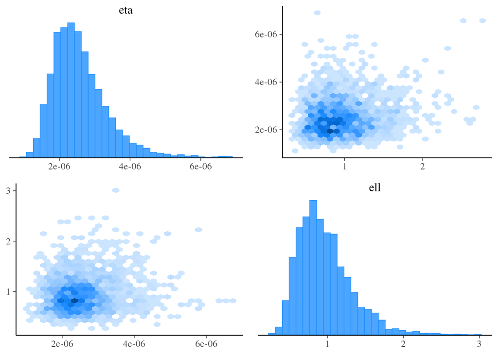

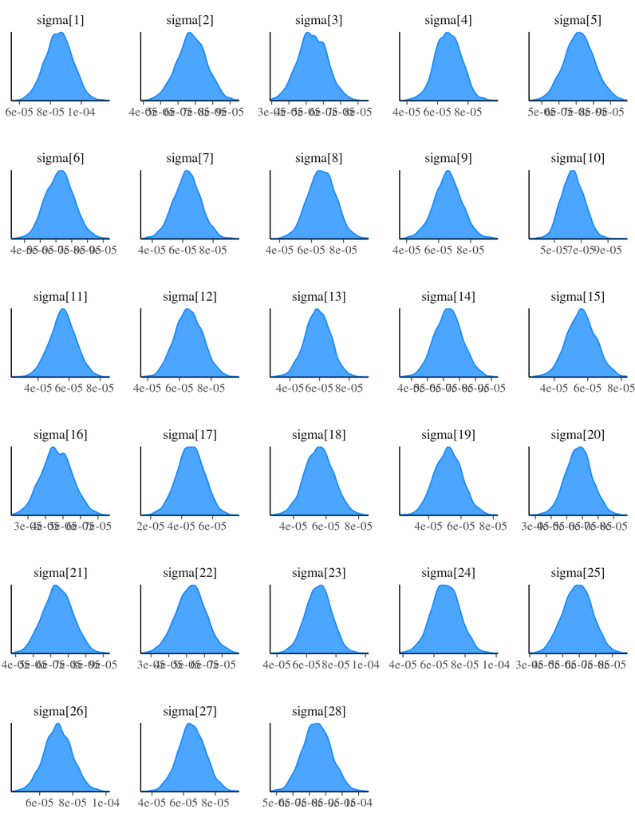

## 3.3 Posterior Predictive Samples

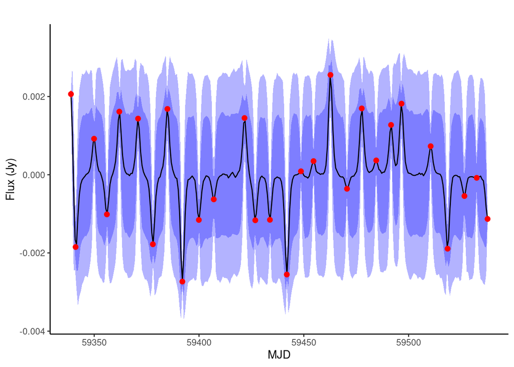

Subtracting the mean from the data before fitting the GP has had a detrimental effect on the model!

## 3.4 PSD

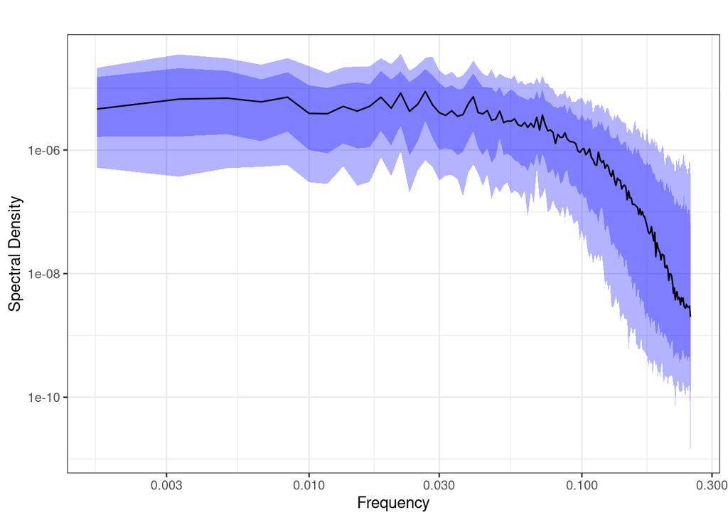

# 4 Non-zero flat mean function Model

- Constant mean function, learned from observations.
- Weak prior on mean function intercept.
- Squared exponential kernel function.
- Heteroskedastic (Gaussian) noise.
- Incorporate data on error in observations of each $y_i$.

$$y_i \sim \mathcal{N}(f(x_i), \sigma_i^2)$$

$$f \sim \mathcal{GP}(C, k(x, x'))$$

$$C \sim \mathcal{U}[-1,1]$$

$$k(x,x') = \eta \exp\left\{ -\frac{1}{2}\frac{(x - x')^2}{\ell^2}\right\}$$

$$\ell \sim \mathrm{InvGamma}(5,5)$$

$$\eta \sim \mathcal{N}^+(0,1)$$

$$\sigma_i \sim \mathcal{N}^+(\textrm{stderr}(y_i), \mathrm{Var}(\textrm{stderr}(\boldsymbol{y})))$$

[output not shown]

## 4.1 MCMC Results

```
 variable     mean   median       sd      mad       q5      q95     rhat
 eta      0.000003 0.000003 0.000001 0.000001 0.000002 0.000004 1.000779
 ell      0.978878 0.917704 0.354865 0.309992 0.523556 1.626577 1.001245
 C        0.058660 0.058664 0.000321 0.000315 0.058135 0.059185 1.001021
 sigma[1] 0.000086 0.000086 0.000009 0.000009 0.000071 0.000100 0.999608
 ess_bulk ess_tail
     4168     2146
     5944     2998
     3874     2768
     5720     2654
```

## 4.2 MCMC Plots

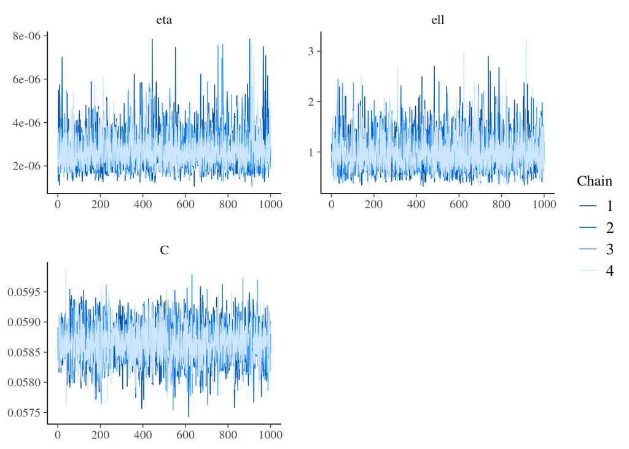

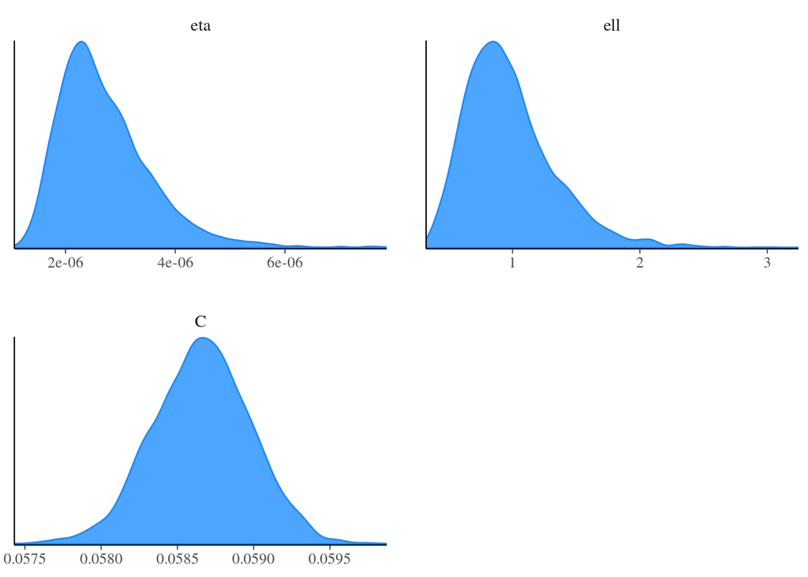

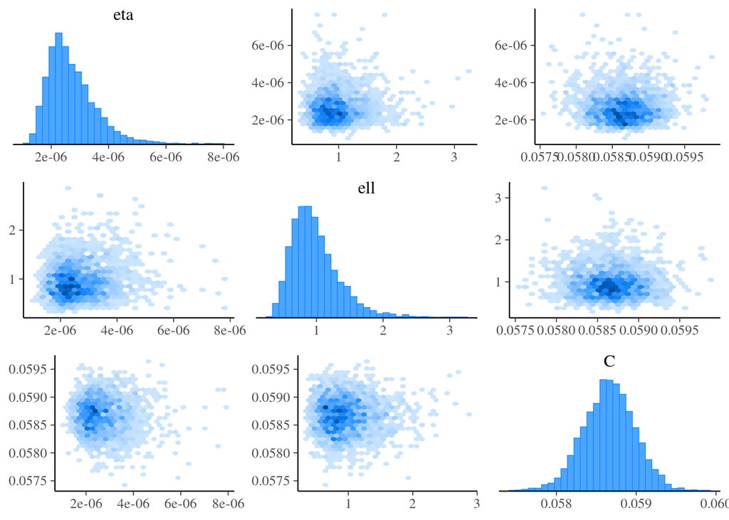

## 4.3 Posterior Predictive Samples

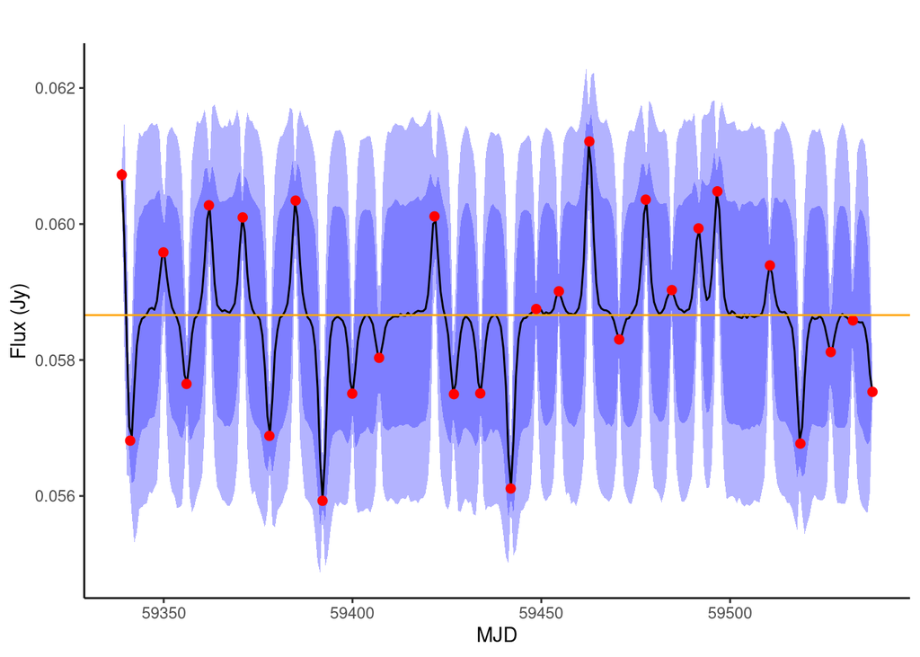

## 4.4 PSD

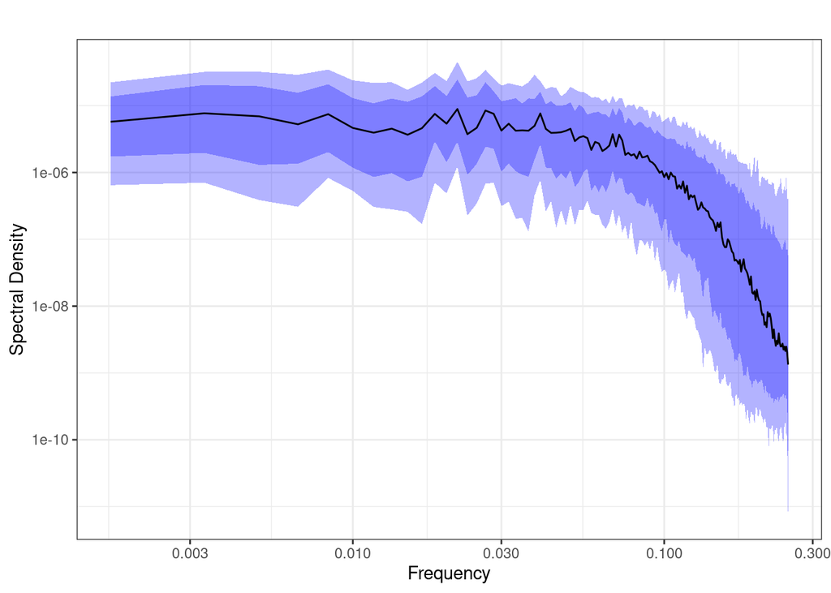

# 5 SE Fixed constant mean function Model

- Constant mean function set at fixed value, e.g., mean of observations.
- Squared exponential kernel function.
- Heteroskedastic (Gaussian) noise.
- Incorporate data on error in observations of each $y_i$.

$$y_i \sim \mathcal{N}(f(x_i), \sigma_i^2)$$

$$f \sim \mathcal{GP}(C, k(x, x')),\quad C \in \mathbb{R}$$

$$k(x,x') = \eta^2 \exp\left\{ -\frac{1}{2}\frac{(x - x')^2}{\ell^2}\right\}$$

$$\ell \sim \mathrm{InvGamma}(5,5)$$

$$\eta \sim \mathcal{N}^+(0,1)$$

$$\sigma_i \sim \mathcal{N}^+(\textrm{stderr}(y_i), \mathrm{Var}(\textrm{stderr}(\boldsymbol{y})))$$

## 5.1 Mean Function = 0.062

```
 variable     mean   median       sd      mad       q5      q95     rhat
 eta      0.003791 0.003726 0.000566 0.000519 0.002989 0.004805 1.000933
 ell      2.221236 1.481030 1.585696 1.117597 0.581530 5.173189 1.003380
 sigma[1] 0.000086 0.000086 0.000009 0.000009 0.000072 0.000100 1.004372
 ess_bulk ess_tail
     3227     1861
     1101     2813
     3912     2315
```

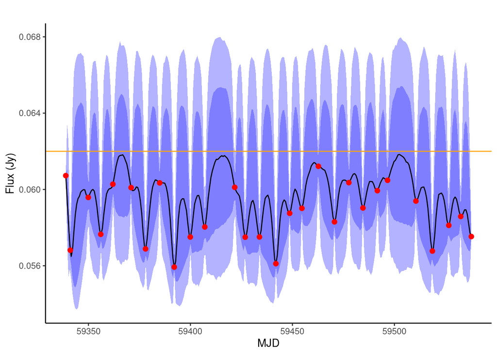

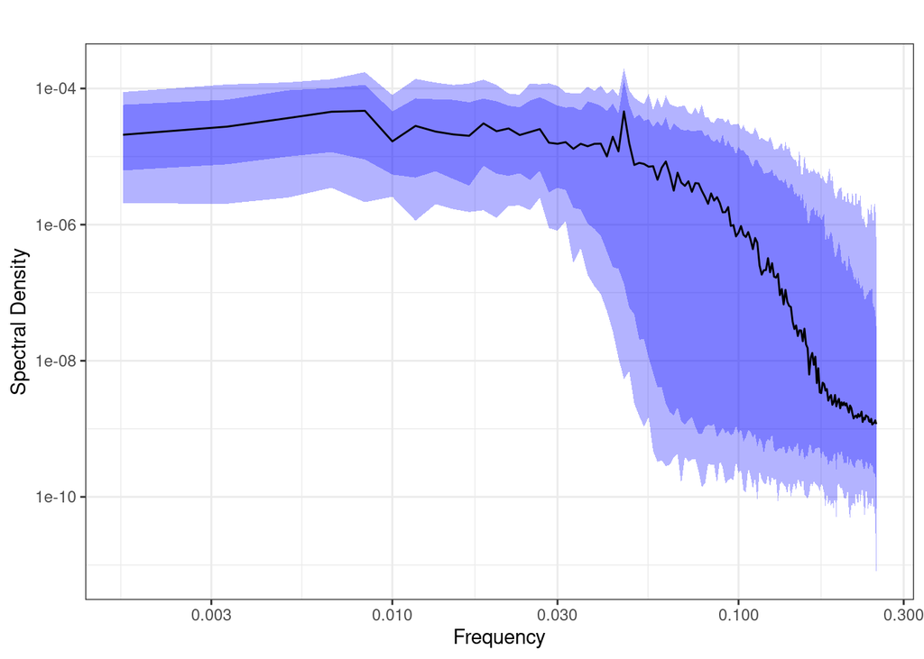

## 5.2 Mean Function = 0.058

```
 variable    mean  median      sd     mad      q5     q95    rhat ess_bulk
 eta      0.00171 0.00168 0.00025 0.00024 0.00135 0.00217 1.00282     6189
 ell      0.99294 0.92153 0.38119 0.33167 0.51186 1.70638 1.00011     5894
 sigma[1] 0.00009 0.00009 0.00001 0.00001 0.00007 0.00010 1.00105     5275
 ess_tail
     2472
     2705
     3102
```

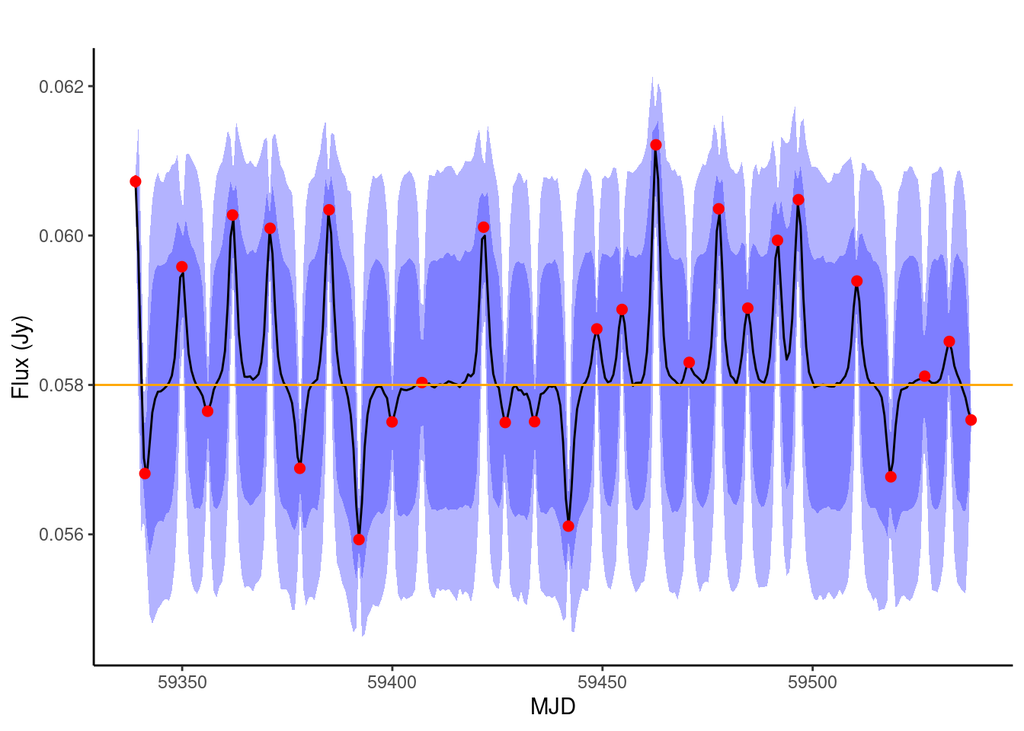

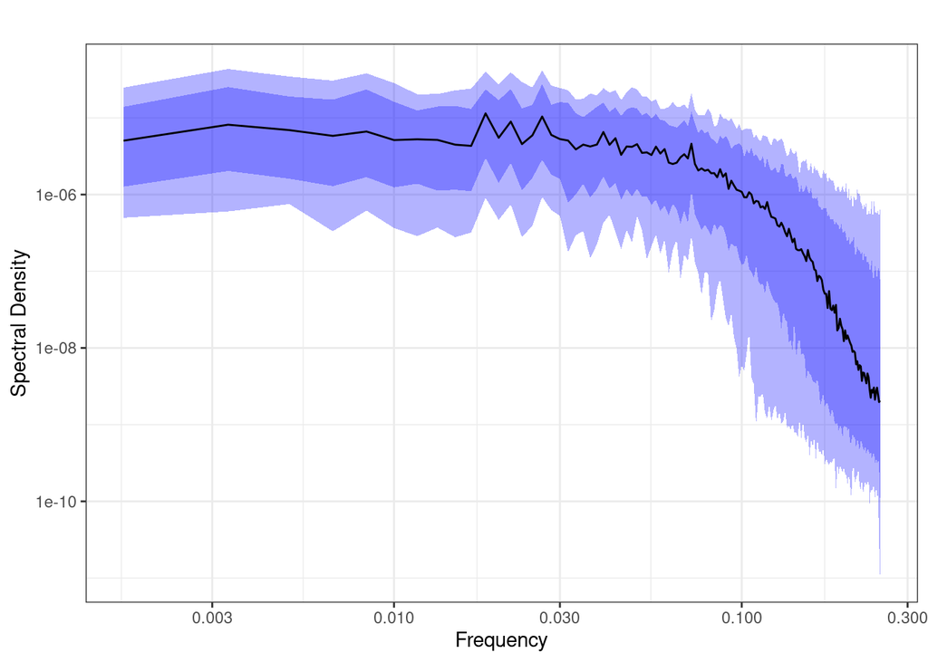

## 5.3 Mean Function = 0.055

```
 variable     mean   median       sd      mad       q5      q95     rhat
 eta      0.004096 0.004031 0.000609 0.000563 0.003247 0.005204 1.000723
 ell      2.103286 1.527850 1.437792 1.116688 0.595973 4.866238 1.001128
 sigma[1] 0.000086 0.000086 0.000008 0.000008 0.000072 0.000100 1.000374
 ess_bulk ess_tail
     6675     2598
     1885     3248
     6137     3030
```

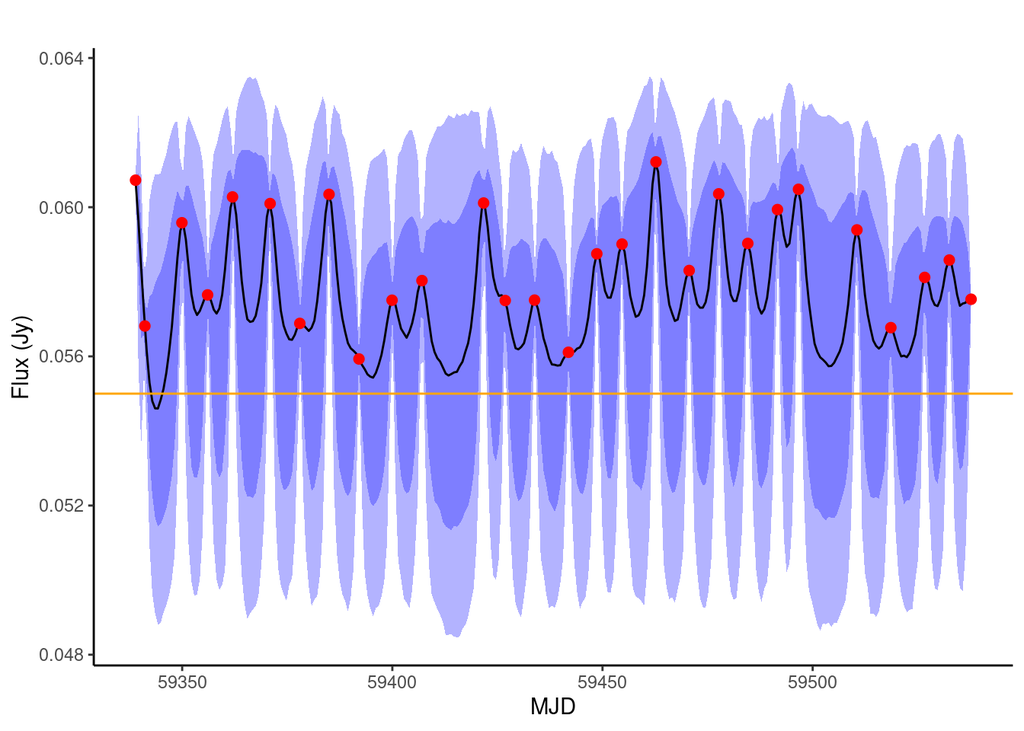

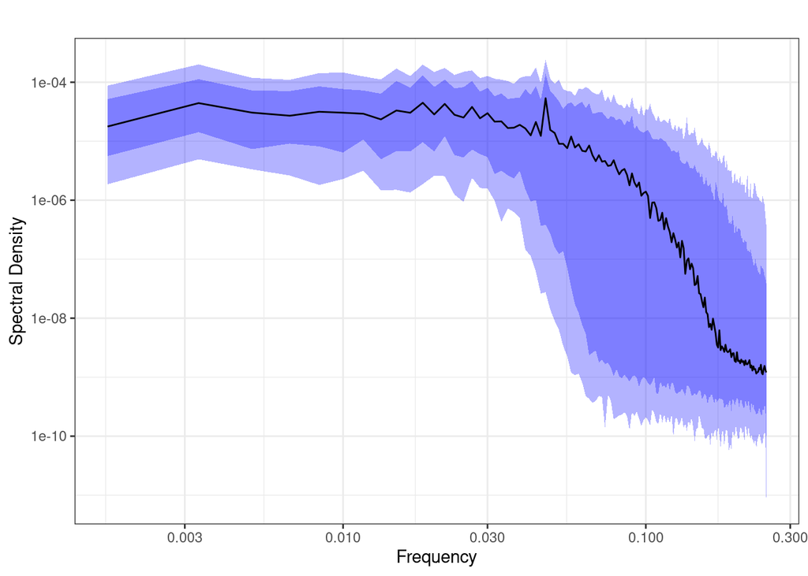